# Integrative GRN inference : model exploration

This document demonstrates the use of the bRF and LASSO-D3S functions for integrative GRN inference.

Those functions infer the regulatory pathways of *Arabidopsis thaliana*’s roots in response to nitrate (N) induction from [Varala et al., 2018](https://www.ncbi.nlm.nih.gov/geo/query/acc.cgi?acc=GSE97500).

They use as inputs the expression profiles of N-responsive genes and TFBS information. Prior TFBS information was built by searching in the promoters of the N-responsive genes the PWM of the N-responsive regulators.

## Data import

### Expression data

Import of the expression data and the N-responsive genes and regulators :

```r
load('rdata/inference_input_N_response_varala.rdata')
genes <- input_data$grouped_genes; length(genes)
```

```
## [1] 1426
```

```r
tfs <- input_data$grouped_regressors; length(tfs)
```

```
## [1] 201
```

```r
counts <- input_data$counts; dim(counts)
```

```
## [1] 1426   45
```

### TFBS data

```r
load("rdata/pwm_occurrences_N_response_varala.rdata")
dim(pwm_occurrence)
```

```
## [1] 1426  201
```

## GRN inference

How does the individual MSE of genes varies with $\alpha$ for model estimation in GRN inferences?

### bRf : biased Random Forests

```r
ALPHAS <- seq(0,1, by = 0.1)
lmses <- data.frame(row.names = genes)

for(alpha in ALPHAS){
  set.seed(121314)
  lmses[,as.character(alpha)] <- bRF_inference_MSE(counts, genes, tfs, alpha = alpha, nTrees = 1000,
                             pwm_occurrence = pwm_occurrence, nCores = 18)
}

save(lmses, file = "results/logMSES_RFs_per_genes.rdata")
```

Clustering the genes :

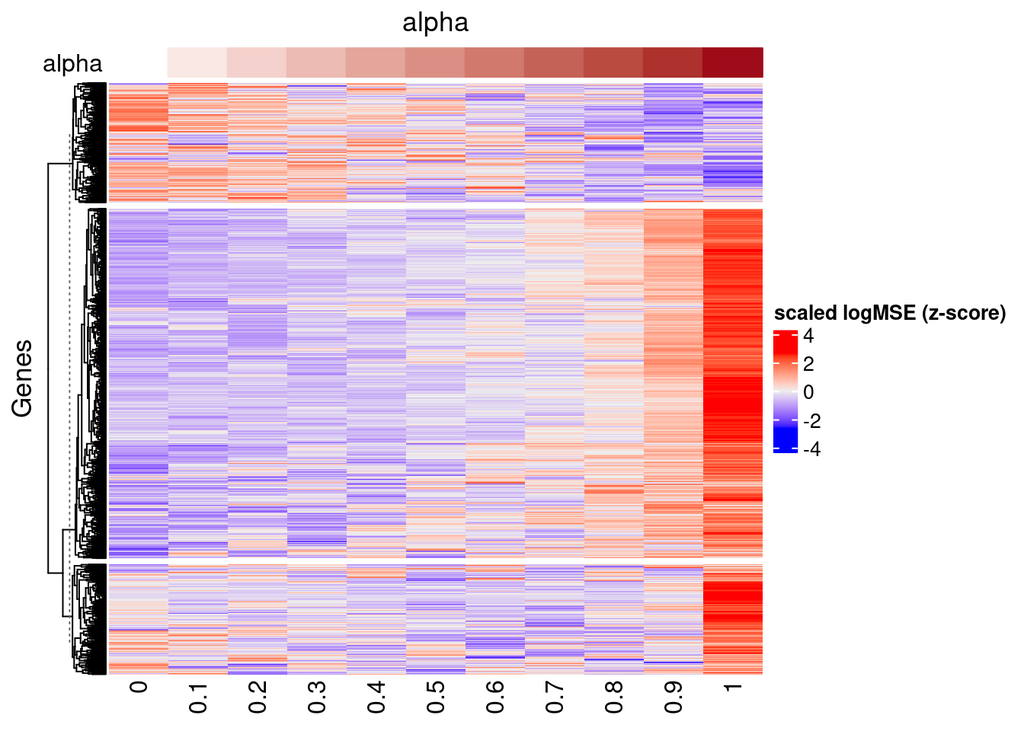

```r
load(file = "results/logMSES_RFs_per_genes.rdata")

mse <- (lmses-rowMeans(lmses)) / matrixStats::rowSds(as.matrix(lmses))

ha = HeatmapAnnotation(
    alpha = anno_simple(as.numeric(rep(colnames(mse),1))),
    annotation_name_side = "left")



heatmap_rf <- Heatmap(mse, row_km = 3, cluster_columns = F, show_row_names = F,
        name = "scaled logMSE (z-score)", top_annotation = ha,
        row_title = "Genes", column_title = "alpha"); heatmap_rf
```

## LASSO-D3S

```r
lmses_lasso <- data.frame(row.names = genes)

for(alpha in ALPHAS){
  set.seed(121314)
  lmses_lasso[,as.character(alpha)] <- LASSO.D3S_inference_MSE(counts, genes, tfs,
                                                               normalized = TRUE,
                                                               alpha = alpha, N = 50,
                               pwm_occurrence = pwm_occurrence, nCores = 15)
}

save(lmses_lasso, file = "results/logMSES_Lasso_per_genes.rdata")
```

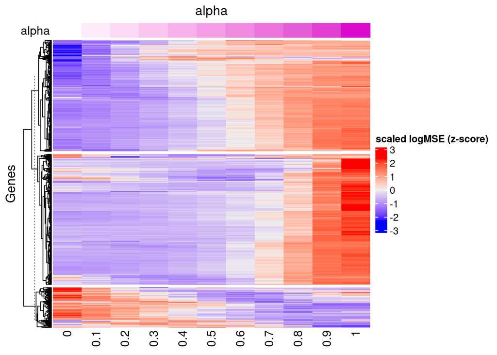

```r
load(file = "results/logMSES_Lasso_per_genes.rdata")
mse_lasso <- (lmses_lasso-rowMeans(lmses_lasso)) / matrixStats::rowSds(as.matrix(lmses_lasso))

ha = HeatmapAnnotation(
    alpha = anno_simple(as.numeric(rep(colnames(mse),1))),
    annotation_name_side = "left")


heatmap_lasso <- Heatmap(mse_lasso, row_km = 3, cluster_columns = F, show_row_names = F,
        name = "scaled logMSE (z-score)", top_annotation = ha,
        row_title = "Genes", column_title = "alpha"); heatmap_lasso
```

## Clustering global des gènes suivant alpha et les deux méthodes

Il semblerait que les gènes dont la MSE diminue ne soient pas les mêmes suivant bRF et LASSO, seul un petit sous ensemble est commun:

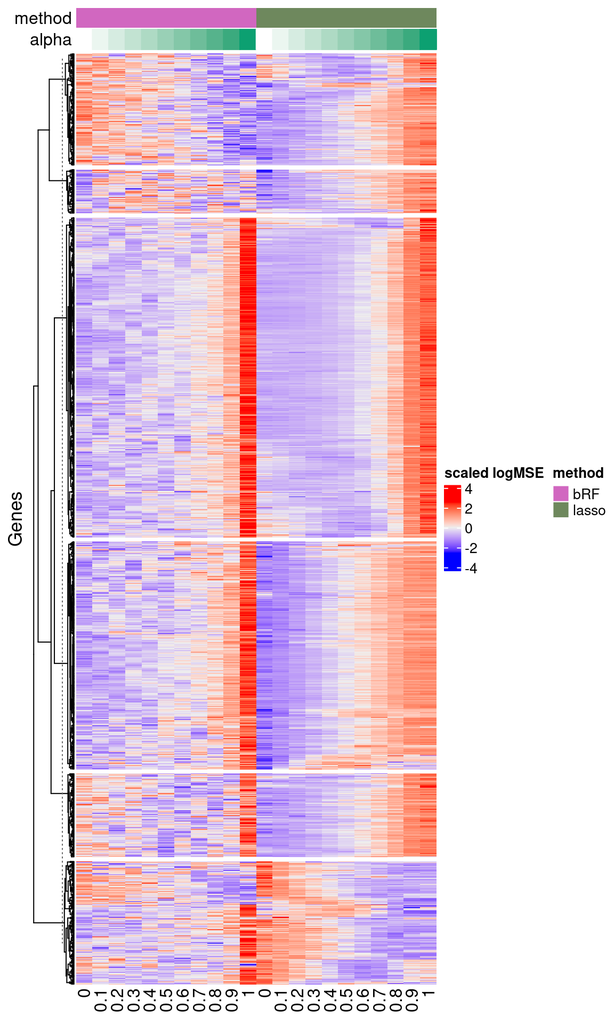

```r
hall = HeatmapAnnotation(
  method = c(rep("bRF", 11), rep("lasso", 11)),
    alpha = anno_simple(as.numeric(rep(colnames(mse),2))),
    annotation_name_side = "left")

Heatmap(cbind(mse, mse_lasso), row_km = 6, cluster_columns = F, show_row_names = F,
        name = "scaled logMSE", top_annotation = hall, clustering_distance_rows = "spearman",
        row_title = "Genes")
```

## Y-a-til des gènes qu’on n’arrive pas à bien prédire, dans aucun cas?

On aimerait exclure ou en tout cas identifier dans ces graphiques s’il y a des gènes que l’on prédit mal quel que soit alpha.

En fait les gènes sur lesquels on se trompe le plus sont aussi les gènes les plus exprimés… Donc on va normaliser la MSE par la variance du gène cible pour avoir des MSE comparables entre gènes.

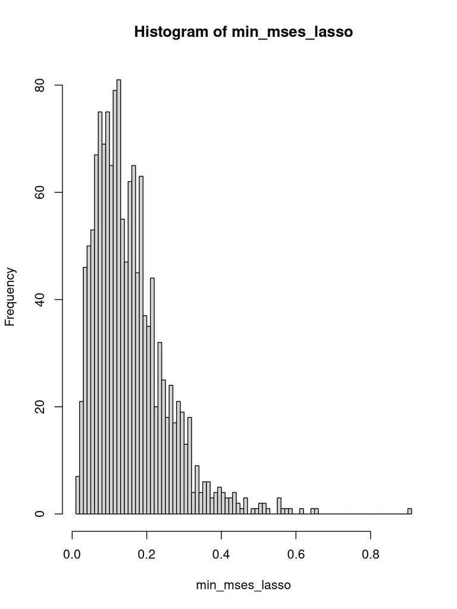

```r
mean_expr <- rowMeans(counts)
var_expr <- matrixStats::rowSds(counts)*matrixStats::rowSds(counts)

all_mses <- cbind(lmses, lmses_lasso)
#all_mses_scaled <- (all_mses-rowMeans(all_mses)) / matrixStats::rowSds(as.matrix(all_mses))
all_mses_scaled <- exp(all_mses) / var_expr

min_mses <- matrixStats::rowMins(as.matrix(all_mses_scaled))

min_mses_lasso <- matrixStats::rowMins(as.matrix(exp(lmses_lasso)/var_expr))
min_mses_rf <- matrixStats::rowMins(as.matrix(exp(lmses)/var_expr))

hist(min_mses_lasso, breaks = 100)
```

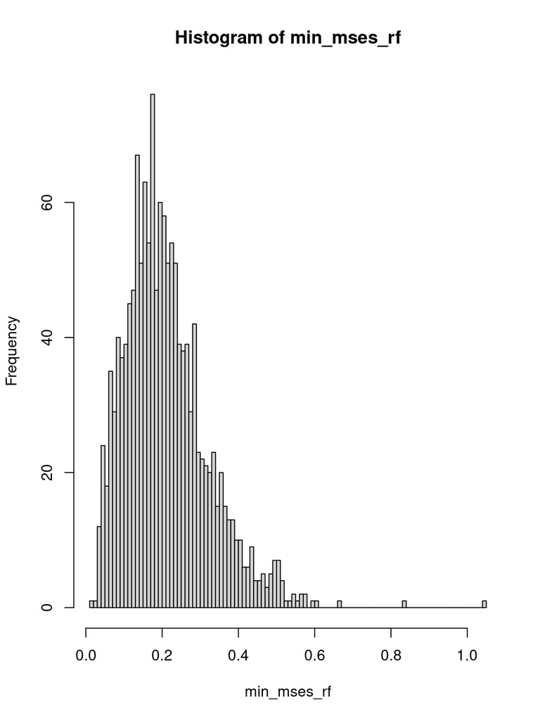

```r
hist(min_mses_rf, breaks = 100)
```

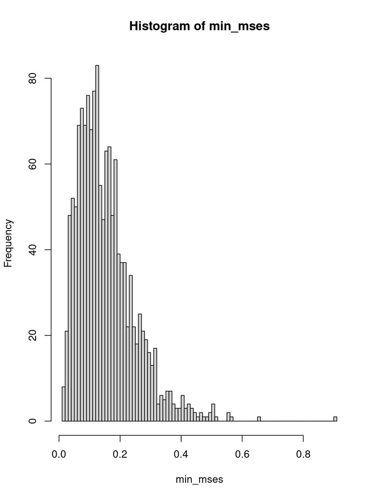

```r
hist(min_mses, breaks = 100)
```

```r
# df <- data.frame(mean_expr)
bad_genes_lasso <- genes[which(min_mses_lasso > 0.3)]
bad_genes_rf <- genes[which(min_mses_rf > 0.3)]


bad_genes_lasso <- min_mses_lasso > 0.3
bad_genes_rf <- min_mses_rf > 0.3

# df$bad <- rownames(df) %in% bad_genes
# df$min_lmse <- min_mses
# ggplot(df, aes(x=bad, y=mean_expr)) + geom_boxplot()
# ggplot(df, aes(x=log(mean_expr), y=min_lmse)) + geom_point()
#
mse_lasso_scaled <- exp(lmses_lasso)/var_expr
mse_rf_scaled <- exp(lmses)/var_expr


# mse_lasso_scaled[bad_genes_lasso>0.3,]<-NA
# mse_rf_scaled[bad_genes_rf>0.3,]<-NA
#

#
# ha = HeatmapAnnotation(
#     alpha = anno_simple(as.numeric(rep(colnames(mse),1))),
#     annotation_name_side = "left")
#
# Heatmap(mse_lasso_scaled, row_km = 0, cluster_columns = F, show_row_names = F,
#         name = "scaled logMSE (z-score)", top_annotation = ha,
#         row_title = "Genes", column_title = "alpha") + rowAnnotation(
#     scaled_min_mse = min_mses_lasso)
#
# Heatmap(mse_rf_scaled, row_km = 0, cluster_columns = F, show_row_names = F,
#         name = "scaled logMSE (z-score)", top_annotation = ha,
#         row_title = "Genes", column_title = "alpha")+ rowAnnotation(
#     scaled_min_mse = min_mses_rf)
```

Sans normaliser par la MSE moyenne par gène, on ne voit plus les variations de MSE liées à alpha, on voit uniquement les gènes qui sont globalement bien ou mal prédits. Deux méthodes simultanément :

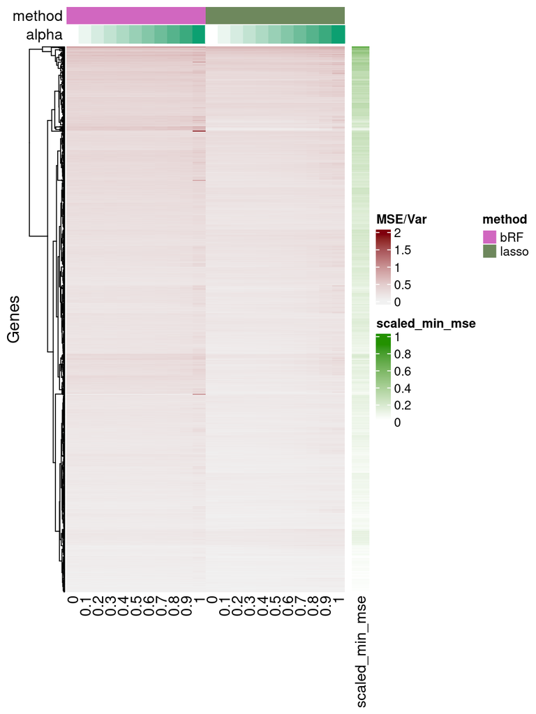

```r
Heatmap(all_mses_scaled, row_km = 0, cluster_columns = F, show_row_names = F,
        name = "MSE/Var", top_annotation = hall, col = rev(hcl.colors(5, palette = "Reds 2")),
        row_title = "Genes")+ rowAnnotation(
    scaled_min_mse = min_mses)
```

Je remets donc un z-score sur la MSE normalisée par gène englobant les deux méthodes, pour visualiser plus précisément les variations de MSE suivant alpha:

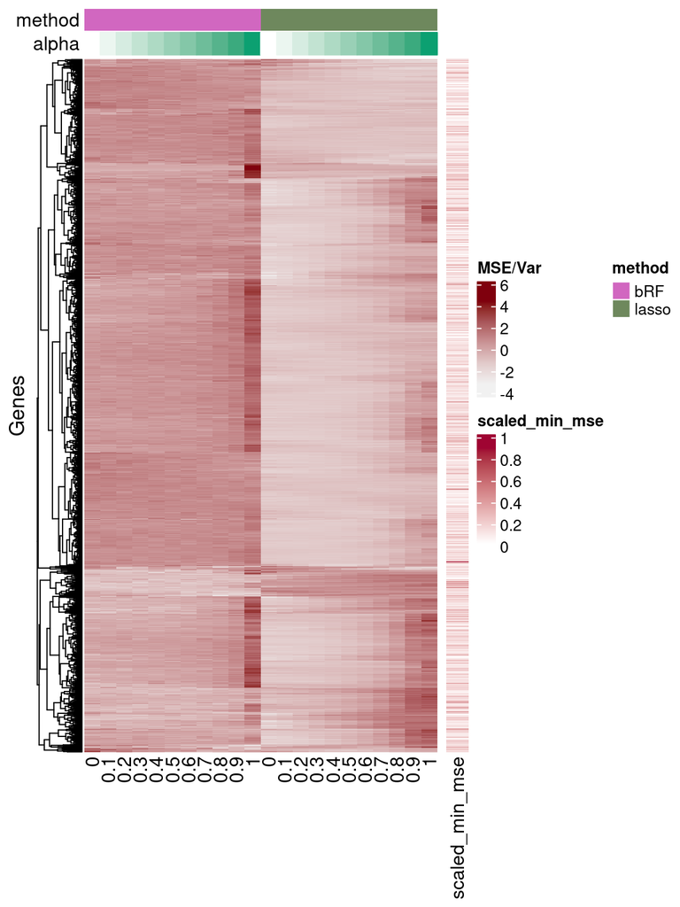

```r
Heatmap((all_mses_scaled-rowMeans(all_mses_scaled))/matrixStats::rowSds(as.matrix(all_mses_scaled)),
        row_km = 0, cluster_columns = F, show_row_names = F,
        name = "MSE/Var", top_annotation = hall, col = rev(hcl.colors(5, palette = "Reds 2")),
        row_title = "Genes")+ rowAnnotation(
    scaled_min_mse = min_mses)
```

En fait, comme le z-score est calculé sur les deux méthodes, on a encore une grosse contribution à la couleur de la différence de MSE inhérente aux deux méthodes, et non à l’effet de l’intégration. Je calcule donc un z-score par méthodes pour faire la représentation:

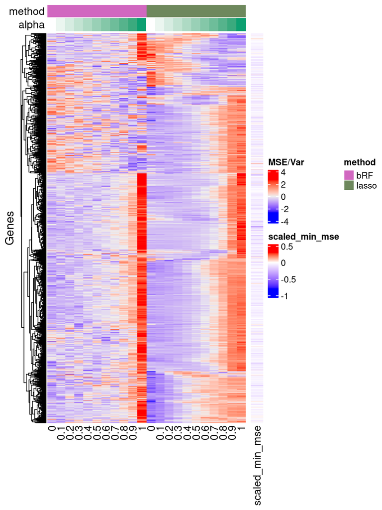

```r
mse_lasso_scaled_zscore <- (mse_lasso_scaled-rowMeans(mse_lasso_scaled, na.rm = T))/matrixStats::rowSds(as.matrix(mse_lasso_scaled, na.rm=T))
mse_rf_scaled_zscore <- (mse_rf_scaled-rowMeans(mse_rf_scaled))/matrixStats::rowSds(as.matrix(mse_rf_scaled))

col_fun = circlize::colorRamp2(c(-0.8, 0, 0.3), c("blue", "white", "red"))


Heatmap(cbind(mse_rf_scaled_zscore, mse_lasso_scaled_zscore),
        row_km = 0, cluster_columns = F, show_row_names = F,
        name = "MSE/Var", top_annotation = hall,
        row_title = "Genes")+ rowAnnotation(
    scaled_min_mse = min_mses_lasso-min_mses_rf, col = list(scaled_min_mse = col_fun))
```

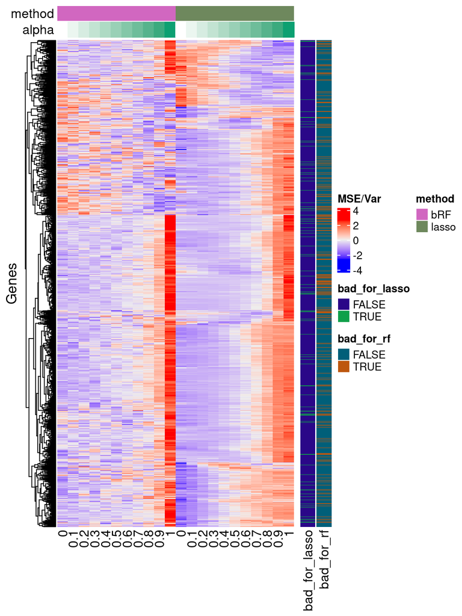

```r
Heatmap(cbind(mse_rf_scaled_zscore, mse_lasso_scaled_zscore),
        row_km = 0, cluster_columns = F, show_row_names = F,
        name = "MSE/Var", top_annotation = hall,
        row_title = "Genes")+ rowAnnotation(
    bad_for_lasso = bad_genes_lasso,
    bad_for_rf = bad_genes_rf)
```

```r
#
#   Heatmap(log(all_mses_scaled), row_km = 0, cluster_columns = F, show_row_names = F,
#         name = "MSE/Var", top_annotation = hall, col = rev(hcl.colors(5, palette = "Reds 2")),
#         row_title = "Genes")+ rowAnnotation(
#     scaled_min_mse = min_mses_lasso-min_mses_rf, col = list(scaled_min_mse = col_fun))
```

> c’est informatif : certains gènes bénéficient de l’intégration de données et d’autres non, et ce n’est pas spécialement lié à si on les prédit bien globalement. Par contre celà dépend visiblement de la méthode utilisée et nous n’avons pas encore d’explication pour ça…

## Faire des clusters informatifs et clairs pour notre question

Définir des groupes suivant l’optimum :

- alpha = 0
- alpha entre 0.1 et 0.4
- alpha entre 0.4 et 0.9
- 1

## Quelles sont les caractéristiques des clusters de gènes

Nombre de motifs dans le promoteur, niveau d’expression, ontologies, sont-ils des TFs? leur taille?

Quelle est la précision rappel des sous réseaux concernant ces gènes.